# Capítulo 20: Agrupación en clústeres K-Medias

Big Data para las Ciencias Sociales

Autores/as

Afiliación

Pedro Jofré  
pedro.jofre_g@mail.udp.cl

Facultad de Ciencias Sociales e Historia  
Universidad Diego Portales

Esperanza Lara  
esperanza.lara_m@mail.udp.cl

Facultad de Ciencias Sociales e Historia  
Universidad Diego Portales

Francisca Pérez  
francisca.perez3@mail.udp.cl

Facultad de Ciencias Sociales e Historia  
Universidad Diego Portales

Catalina Soza  
catalina.soza1@mail.udp.cl

Facultad de Ciencias Sociales e Historia  
Universidad Diego Portales

Carla Vidal  
carla.vidal_r@mail.udp.cl

Facultad de Ciencias Sociales e Historia  
Universidad Diego Portales

Fecha de publicación

07 de julio, 2024

**Click para ver el código**

```r
# Código de ajustes

rm(list = ls()) # Limpiamos la memoria
options(scipen = 999) # Desactivamos la notación científica
options(knitr.kable.NA = '') # NA en blanco

# Librerías utilizadas
library(rio)
library(tidyverse)
```

# Capítulo 20: Agrupación en clústeres K-Medias

En la tercera parte de este libro nos centramos en los métodos para reducir la dimensión de nuestro espacio de características $(p)$. Los capítulos restantes se refieren a los métodos para reducir la dimensión de nuestro espacio de observación $(n)$. Estos métodos se conocen comúnmente como métodos de agrupación. Hacer agrupaciones de K-medias es uno de los algoritmos más utilizados para dividir la cantidad de observaciones en un conjunto de $K$ grupos (es decir, K clústeres), donde el número de K (clústeres) es definido y especificado por los investigadores. Realizar clpuesteres de K-Medias, al igual que otros algoritmos de agrupación de datos, clasifica las observaciones en grupos (o conglomerados) mutuamente excluyentes, de modo que las observaciones dentro del mismo conglomerado sean lo más similares entre sí (es decir, alta similitud intraclase), mientras que las observaciones de diferentes conglomerados son lo más diferentes posible (es decir, baja similitud entre clases). En la agrupación por el método de K-Medias, cada clúster es definido por su centro (es decir, centroide) que corresponde a la media de la distancia entre el centro del cluster y sus datos más próximos. El procedimiento utilizado para encontrar estos conglomerados es similar al algoritmo `k-nearest` más cercano (KNN), el cual se discute en el Capítulo 8, aunque sin la necesidad de tener que predecir un valor de respuesta promedio.

## 20.1 Prerequisitos

Para este capítulo usaremos los siguientes paquetes (para esto es necesario tener en cuenta que la función principal para realizar Clústers de K-Medias, `kmeans()`, se encuentra incluida en el paquete **stats** que viene con la instalación básica de R):

**Click para ver el código**

```r
#Paquetes de ayuda para realizar el procedimiento

library(haven)      #Para cargar las bases de datos
library(dplyr)      #Para manipulación de datos
library(ggplot2)    #Para visualizar los datos
library(stringr)    #Para funcionalidad en cadena

#Paquetes de modelamiento de datos

library(cluster)    #Para algoritmos de clusters en general
library(factoextra) #Para visualizar los resultados del modelamiento de clusters
```

Para ilustrar el concepto de Cluster de *K-Medias*, usaremos la base de datos base_o. Esta base de datos corresponde a la **Décima Encuesta Nacional de Juventudes realizada** el año **2022** por el **Instituto Nacional de la Juventud (INJUV).** De la base de datos se seleccionó la que corresponde a adultos, es decir, personas entre 30 y 59 años. Se utilizó un set de preguntas, que abarcan opiniones sobre temas presentes en el debate público como la legalización de la marihuana, matrimonio igualitario, determinación indígena, etc. Las preguntas seleccionadas del cuestionario corresponden a las del módulo `P10`, todas las preguntas son sobre grados de acuerdo que van del 1 al 5, en donde 1 es “muy en desacuerdo” y 5 “muy de acuerdo.

Con esta base y estas preguntas se espera identificar el perfil valórico de adultos que respondieron la encuesta. Para seleccionaremos solo las variables que vamos a utilizar y las adjuntaremos en una base de datos nueva, más reducida. Además se hará limpieza y preparación de datos para manipular la base.

**Click para ver el código**

```r
# Se carga la base de datos

library(haven)

base_o <- read_dta("C:/Users/vidal/Desktop/K-Medias BD/Kmedias-BD/K medias Grupo 6/base adultos/Adultos/BBDD Respuesta - Encuestas Adultos.dta")

#Se filta la base de datos para que solo se utilicen las variables necesarias

base_o[base_o == 98 | base_o == 99] <- NA #Recodificar valores 98 y 99 como NA.

baseoficial <- base_o %>%
  select(SEXO, P61, P13, P20, P10_1, P10_2, P10_3, P10_4, P10_5, P10_6, P10_7)

# Limpieza de datos
baseoficial <- na.omit(baseoficial)

# Base con la que se realizaran los clusters. Solo contiene los datos del set de preguntas P10

basefiltradisima <- baseoficial %>%
  select(P10_1, P10_2, P10_3, P10_4, P10_5, P10_6, P10_7)


#Recodificacion y etiquetado de los datos para un analisis descriptivo de los clusteres creados

baseoficial <- baseoficial %>%
  mutate(nvl_educ = case_when(P13 == 1 ~ 1,
                              P13 >= 2 & P13 <= 6 ~ 2,
                              P13 >= 7 & P13 <= 10 ~ 3,
                              P13 >= 11 & P13 <= 16 ~ 4,
                              TRUE ~ NA),
         nvl_educ = factor(nvl_educ, levels = 1:4 ,labels = c("no asistio", "media imcompleta", "media completa", "superior")),
         pospol = case_when(P20 == 6 ~ 4, #sin identificacion
                            P20 <= 2 ~ 1, #derecha
                            P20 == 3 ~ 2, #centro
                            P20 %in% 4:5 ~ 3, #izquierda
                            TRUE ~ NA),
         pospol = factor (pospol, levels = 1:4, labels = c("derecha", "centro", "izquierda", "sin identificacion")),
         genero = case_when(P61 == 1 ~ 1, #masculino
                            P61 == 2 ~ 2, #femenino
                            P61 == 3 ~ 1, #masculino
                            P61 == 4 ~ 2, #femenino
                            TRUE  ~ 3), #otros
         genero = factor(genero, levels = 1:3, labels = c("masculino","femenino","otro")))
```

## 20.2 Definición de las medidas de distancia

La clasificación de los datos en grupos requiere de algún método para calcular la distancia entre cada par de observaciones y su centro.

Entonces, ¿cómo se decide una medida de distancia en particular? Desafortunadamente, no hay una respuesta directa y entran en juego varias consideraciones.

La distancia euclidiana (es decir, la distancia en línea recta, o en línea recta) es muy sensible a los valores atípicos. Estos valores pueden sesgar los resultados del agrupamiento, lo que da una falsa confianza en la compacidad del conglomerado. Si las entidades siguen una distribución gaussiana aproximada, la distancia euclidiana es una medida razonable para usar. Sin embargo, si sus entidades se desvían significativamente de la normalidad o si simplemente desea ser más robusto con respecto a los valores atípicos existentes, las distancias de Manhattan, Minkowski o Gower suelen ser mejores opciones.

Si se está analizando datos sin escala, donde las observaciones pueden tener grandes diferencias de magnitud, pero un comportamiento similar, es preferible usar una distancia basada en la correlación. Por ejemplo, supongamos que desea agrupar a los clientes en función de características de compra comunes. Es posible que los clientes de gran volumen y de bajo volumen muestren comportamientos similares; Sin embargo, debido a su magnitud de compra, la escala de los datos puede sesgar los clústeres si no se utiliza una medida de distancia basada en la correlación. La figura 20.1 ilustra este fenómeno en el que las observaciones uno y dos compran cantidades similares de artículos; sin embargo, las observaciones dos y tres tienen una correlación casi perfecta en su comportamiento de compra. Una medida de distancia sin correlación agruparía las observaciones uno y dos, mientras que una medida de distancia basada en la correlación agruparía las observaciones dos y tres.

Figura 20.1: Las medidas de distancia basadas en la correlación capturarán la correlación entre dos observaciones mejor que una medida de distancia no basada en la correlación; independientemente de las diferencias de magnitud.

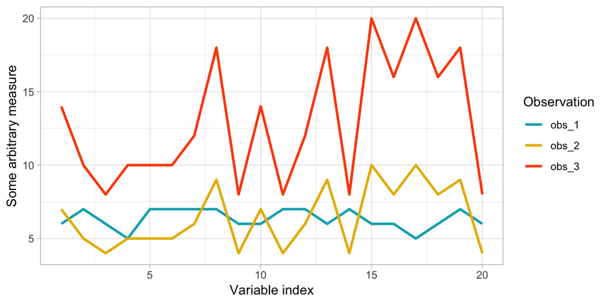

## 20.3 Definición de clústeres

La idea básica detrás de la agrupación en clústeres k-medias es construir clústeres de modo que se minimice la variación total dentro del clúster. Hay varios algoritmos k-means disponibles para hacer esto. El algoritmo estándar es el algoritmo de Hartigan-Wong (Hartigan y Wong 1979), que define la variación total dentro del conglomerado como la suma de las distancias euclidianas entre los valores de las características de la observación i y el centroide correspondiente:

$$\begin{equation}
\tag{20.1}
W\left(C_k\right) = \sum_{x_i \in C_k}\left(x_{i} - \mu_k\right) ^ 2,
\end{equation}$$

Donde:

- $x_i$ es una observación perteneciente al cúmulo $C_k$
- $\mu_k$ es el valor promedio de los puntos asignados al cluster $C_k$

Cada observación $(x_1)$ se asigna a un conglomerado dado de modo que se minimiza la suma de las distancias al cuadrado (SS) de cada observación a sus centros de conglomerado asignado $(\mu_k)$.

Definimos la variación total dentro del clúster de la siguiente manera:

$$\begin{equation}
\tag{20.2}
SS_{within} = \sum^k_{k=1}W\left(C_k\right) = \sum^k_{k=1}\sum_{x_i \in C_k}\left(x_i - \mu_k\right)^2
\end{equation}$$

El $SS\_{within}$ mide la compacidad (es decir, la bondad) de los grupos resultantes y queremos que sea lo más pequeño posible, como se ilustra en la Figura 20.2.

Figura 20.2: Variación total dentro del conglomerado captura las distancias totales entre el centroide de un conglomerado y las observaciones individuales asignadas a ese conglomerado. Cuanto más compactas son estas distancias, más definidos y aislados están los cúmulos.

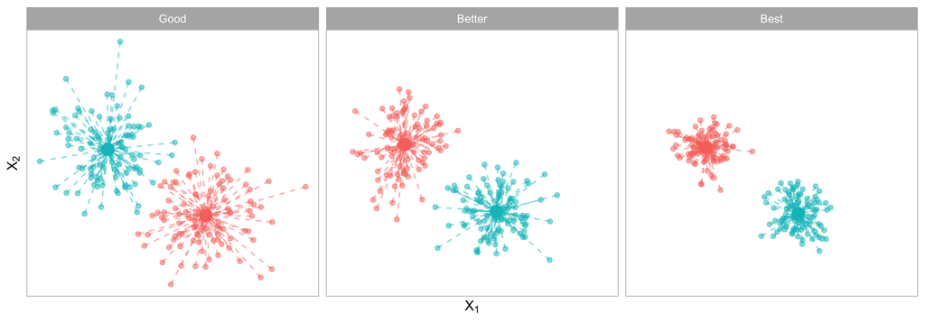

El método de k-medias asume que los puntos están más cerca de su propio centro de clúster que de otros centros. Sin embargo, esta suposición puede fallar cuando los clústeres tienen formas complicadas, ya que k-medias requiere límites convexos. Por ejemplo, en la Figura 20.3 (A), los datos están claramente agrupados, pero sus agrupaciones no tienen límites convexos definidos. Debido a esto, el método de k-medias no logra capturar los grupos adecuados, como se muestra en la Figura 20.3 (B).

Para solucionar este problema, los métodos de agrupamiento espectral utilizan el mismo truco de kernel discutido en el Capítulo 14, permitiendo que k-medias descubra límites no convexos, como se ilustra en la Figura 20.3 (C). Para una discusión exhaustiva sobre el agrupamiento espectral, se puede consultar a Friedman, Hastie y Tibshirani (2001), y el paquete “kernlab” proporciona una implementación en R.

En el Capítulo 22, también abordaremos métodos de agrupamiento basados en modelos, que ofrecen una alternativa para capturar formas de clúster no convexas.

Figura 20.3: Los supuestos de k-means lo hacen ineficaz para capturar agrupaciones geométricas complejas; Sin embargo, la agrupación en clústeres espectral permite agrupar datos que están conectados, pero no necesariamente agrupados dentro de límites convexos.

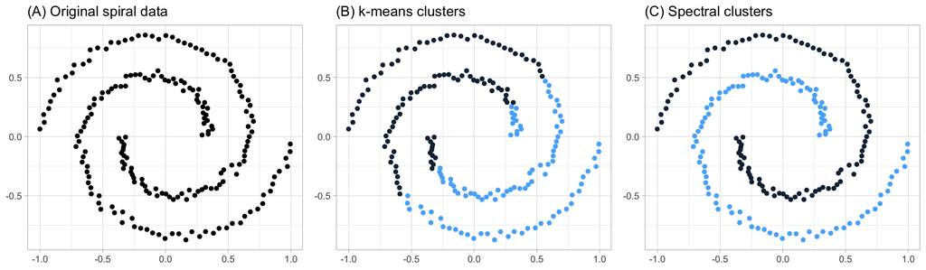

## 20.4 El algoritmo de K-Medias

El primer paso al usar el método de agrupación en clústeres k-means es determinar el número de clústeres (k) que se formarán en la solución final. Desafortunadamente, a menos que nuestro conjunto de datos sea muy pequeño, no podemos evaluar todas las posibles combinaciones de agrupaciones, ya que existen casi $k^n$ formas diferentes de dividir $n$ observaciones en $k$ clústeres. Por lo tanto, necesitamos encontrar una solución óptima local utilizando un enfoque codicioso para el $k$ especificado (Hartigan y Wong 1979).

Para ello, el algoritmo comienza seleccionando aleatoriamente $k$ observaciones del conjunto de datos, que servirán como los centros iniciales de los clústeres, también conocidos como centroides. Luego, cada una de las observaciones restantes se asigna a su centroide más cercano. La cercanía se define utilizando la distancia entre la observación y la media del clúster, basada en la medida de distancia seleccionada. Este proceso se llama el paso de asignación de clúster.

El siguiente paso en el algoritmo k-means es calcular el nuevo centro, o valor medio, de cada clúster. Este proceso se llama actualización de centroide. Una vez recalculados los centros, cada observación se revisa nuevamente para determinar si podría estar más cerca de un clúster diferente. Las observaciones se reasignan utilizando las medias de los clústeres actualizados. Los pasos de asignación de clústeres y actualización de centroides se repiten de forma iterativa hasta que las asignaciones de clústeres dejan de cambiar, es decir, cuando se logra la convergencia. Esto ocurre cuando los clústeres formados en la iteración actual son los mismos que los obtenidos en la iteración anterior.

Debido a la aleatorización de las observaciones $k$ iniciales utilizadas como centroides iniciales, podemos obtener resultados ligeramente diferentes cada vez que aplicamos el procedimiento. En consecuencia, la mayoría de los algoritmos utilizan varios inicios aleatorios y eligen la iteración con el $W\left(C_k\right)$ más bajo (Ecuación (20.1)). La figura 20.4 ilustra la variación en $W\left(C_k\right)$ para diferentes inicios aleatorios.

- **Una buena regla para el número de inicios aleatorios que se deben aplicar es de 10 a 20.**

Figura 20.4: Cada aplicación del algoritmo k-means puede lograr ligeras diferencias en los resultados finales en función del inicio aleatorio.

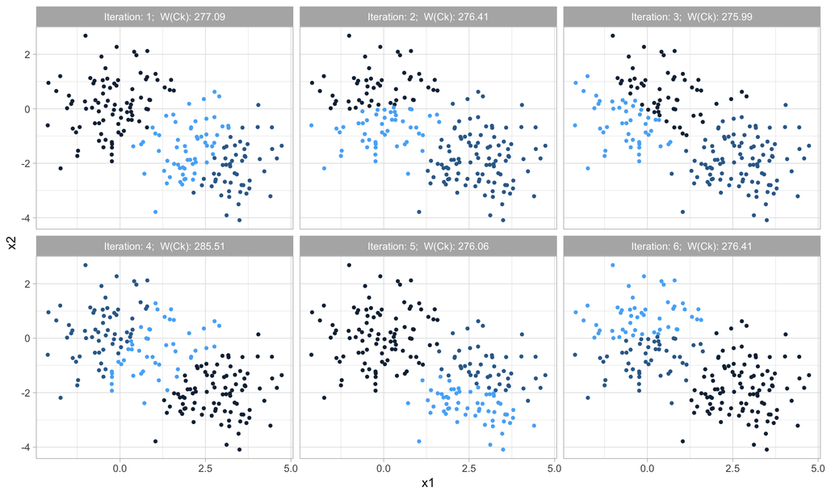

Para llevar a cabo un algoritmo de K-Medias se deben seguir los siguientes pasos:

1. Especifique el número de clústeres $(k)$ que se van a crear (esto lo hace el analista).
2. Seleccione observaciones $k$ al azar del conjunto de datos para utilizarlas como centroides de clúster iniciales.
3. Asigne cada observación a su centroide más cercano en función de la medida de distancia seleccionada.
4. Para cada uno de los clústeres $k$, actualice el centroide del clúster calculando los nuevos valores medios de todos los puntos de datos del clúster. El centroide para el $i$-ésimo grupo es un vector de longitud $p$ que contiene las medias de todas las características p para las observaciones del clúster $i$.
5. Minimice de forma iterativa $SS_{within}$. Es decir, itere los pasos 3 y 4 hasta que las asignaciones de clúster dejen de cambiar (más allá de algún umbral) o se alcance el número máximo de iteraciones. Una buena regla general es realizar de 10 a 20 iteraciones.

## 20.5 ¿Cuántos clústeres?

Al agrupar los datos de la base de datos `basefiltradisima` el número de clústeres que especificamos se puede basar en el conocimiento previo de los mismos. Sin embargo, a menudo no tenemos este tipo de información *a priori* y la razón por la que estamos realizando análisis de conglomerados es para identificar qué grupos pueden existir. Entonces, ¿cómo se determina el número correcto de k?

- La elección del número de clústeres requiere un delicado equilibrio. Los valores más altos de $k$ pueden mejorar la homogeneidad de los clústeres; sin embargo, se corre el riesgo de sobre ajustar.

En la mejor situación, o quizás deberíamos decir la opción más sencilla, k ya está establecido de antemano. Esta circunstancia es frecuente cuando contamos con recursos determinados para asignar. Por ejemplo, una empresa puede tener un número fijo de vendedores, $k$, y desea categorizar a sus clientes en uno de los $k$ segmentos para asignarlos a uno de los vendedores. En esta situación, $k$ está predefinido por recursos o información externa disponible.

Un caso más común es que $k$ es desconocido. Sin embargo, usualmente todavía se puede aplicar el conocimiento *a priori* para plantear agrupaciones potenciales. Por ejemplo, si se necesita agrupar las respuestas de una encuesta sobre experiencias de clientes para una empresa de venta de automóviles, se puede comenzar definiendo $k$ de acuerdo el número de marcas de automóviles que tiene una empresa.

Si no tiene ningún conocimiento a priori para establecer $K$, entonces una regla general de uso común es $k = \sqrt{n/2}$ donde $n$ es elnúmero de observaciones a agrupar. Sin embargo, esta regla puede dar lugar a valores muy grandes de $k$ para conjuntos de datos más grandes.

Cuando el objetivo del procedimiento de agrupamiento es determinar qué grupos distintos naturales existen en los datos, sin ningún conocimiento a priori, existen múltiples métodos estadísticos que podemos aplicar. Sin embargo, muchas de estas medidas sufren *la maldición de la dimensionalidad*, ya que requieren múltiples iteraciones y la agrupación en clústeres de grandes conjuntos de datos no es eficiente, especialmente cuando se agrupa repetidamente.

- Véase Charrad et al. (2015) para una revisión exhaustiva de la amplia variedad de medidas del rendimiento de los clústeres. El paquete`NbClust` implementa muchos de estos métodos, proporcionándole más de 30 índices para determinar un $k$ óptimo.

En este sentido, siguiendo con el ejemplo del perfil valórico de adultos chilenos, en ese caso en particular es posible determinar *a priori* una posible cantidad de clústeres gracias al conocimiento previo. Sin embargo, el método que se decidió utilizar para determinar el número de clusters con la base de datos `basefiltradisima` es el *método del codo*.

Pasos a seguir:

1. Calcule la agrupación en clústeres de k-medias para diferentes valores de k. Por ejemplo, variando k de 1 a 20 clústeres.
2. Para cada k, calcule la suma total de cuadrados dentro del clúster (WSS).
3. Grafique la curva de WSS de acuerdo con el número de clústeres k.
4. La ubicación de una curva (es decir, un codo) en la parcela generalmente se considera como un indicador del número apropiado de clústeres.

A continuación, se evalúa la agrupación de los datos de `basefiltradisima` en 1 a 15 clústeres. El argumento `method = 'wss'` especifica que neustro criterio de búsqueda utiliza el método del codo discutido anteriormente. Dado que estamos evaluando las respuestas de la pregunta `P10` de la encuesta realizada por INJUV (2022), usamos la distancia euclidiana, ya que es la más comunmente utilizada a la hora de evaluar el número de clústeres. Los resultados muestran que el “codo” para ocurrir más claramente cuando $k = 2$.

**Click para ver el código**

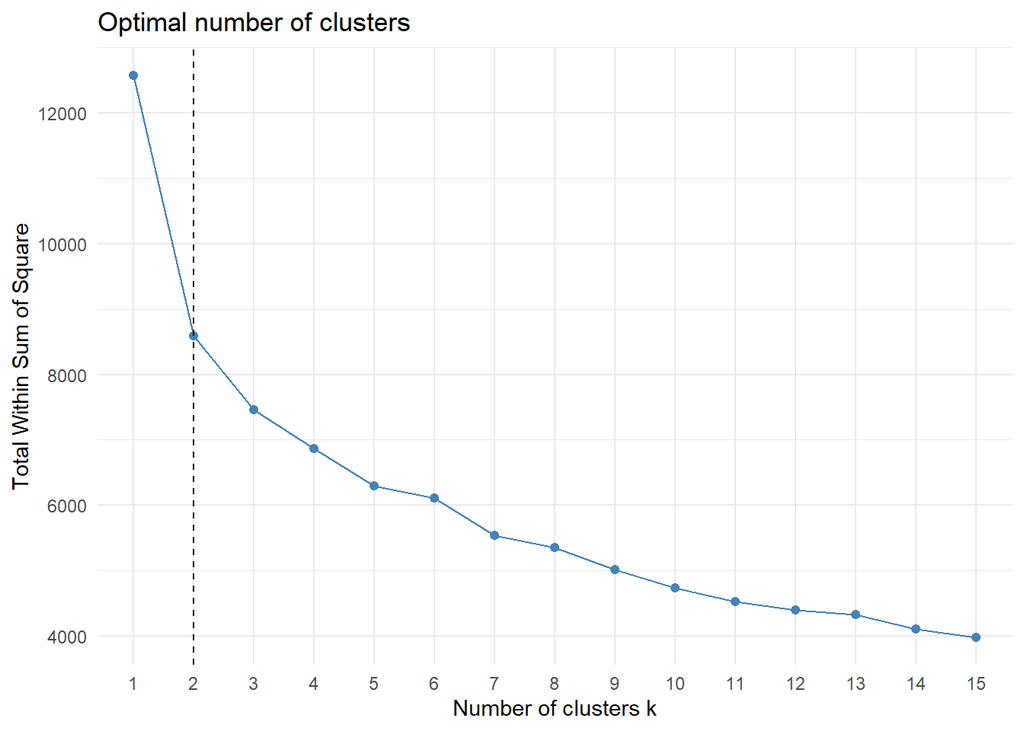

```r
# Para iniciar la construcción de los clústeres.

set.seed(123)

model.km <- kmeans(basefiltradisima,
                   iter.max=6,
                   centers=2,
                   nstart=100,
                   trace = FALSE)

model.km

basefiltradisima$cluster_kmedias <- model.km$cluster

# grafico de codo
fviz_nbclust(basefiltradisima,
             kmeans,
             k.max = 15,
             method = "wss",
             diss = get_dist(basefiltradisima, method = "euclidean")) +
  geom_vline(xintercept = 2,linetype = "dashed", color = "black") +  #grafico codos
  theme_minimal()
```

**Click para ver el código**

```r
baseoficial$cluster_kmedias <- model.km$cluster
```

Figura 20.7: Uso del método del codo para identificar el número preferido de clústeres en el conjunto de datos de perfil valórico de chilenos/as.

`fviz_nbclust()` también implementa otros métodos populares como el método de la silueta (Rousseeuw, [1987](https://bradleyboehmke.github.io/HOML/kmeans.html#ref-rousseeuw1987silhouettes)) y el estadístico de brecha (Tibshirani et al., [2001](https://bradleyboehmke.github.io/HOML/kmeans.html#ref-tibshirani2001estimating)). Afortunadamente, las aplicaciones que requieren el conjunto óptimo exacto de clústeres son bastante raras. En la mayoría de las aplicaciones, basta con elegir un $k$ en función de la conveniencia en lugar de los estrictos requisitos de rendimiento. De ser necesario, el método del codo y otros métodos pueden ayudar a indicar la dirección correcta a la hora de decidir cuántos clústeres hacer.

A través del método del codo, específicamente utilizando el código `factoextra::fviz_nbclust()`se determinó 2 clústeres como la medida más óptima para agrupar el conjunto de datos `basefiltradisima`. En este caso se ven claramente dos perfiles valóricos al graficar los clusters.

## 20.6 Graficar clústers y visualización de resultados

Habiendo determinado el número de clusters, se procede a graficar para visualizar la distribución de los datos.

**Click para ver el código**

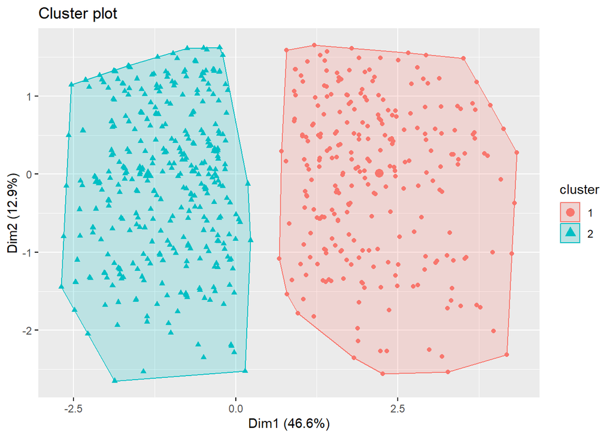

```r
# Grafico de los clusters
fviz_cluster(model.km, data = basefiltradisima, geom = "point")
```

**Click para ver el código**

```r
# Para comprender mejor los grupos
aggregate(baseoficial[1:4], by=list(model.km$cluster), median)
```

[output not shown]

Se vuelve necesario recordar que la base de datos utilizada corresponde a un set de preguntas sobre posición valórica respecto a diversos temas presentes en el debate público. Para conocer más en profundidad cómo se componen los clusters, se realizaron análisis descriptivos de acuerdo a tres variables ya recodificadas al inicio del capítulo, estas son: `género`, `posición política` y `nivel educacional`. Para conocer los descriptivos se aplica el siguiente código.

**Click para ver el código**

```r
#tabla n°1
# Reportamos con una librería de forma directa
library(vtable)
var_stat1 <- baseoficial %>% select(nvl_educ,pospol,genero,cluster_kmedias)

st(var_stat1, digits = 3, out="kable",
fixed.digits = TRUE,
simple.kable = TRUE,
group = "cluster_kmedias",
title="Estadísticos Descriptivos.",
numformat = NA) %>%
kableExtra::kable_styling(latex_options = c("scale_down", "hold_position"),
full_width = FALSE, fixed_thead = T)
```

Estadísticos Descriptivos.

| Variable | N | Percent | N | Percent |
| --- | --- | --- | --- | --- |
| cluster_kmedias | 1 |  | 2 |  |
| nvl_educ | 323 |  | 528 |  |
| ... no asistio | 1 | 0.3% | 1 | 0.2% |
| ... media imcompleta | 50 | 15% | 54 | 10% |
| ... media completa | 184 | 57% | 292 | 55% |
| ... superior | 88 | 27% | 181 | 34% |
| pospol | 323 |  | 528 |  |
| ... derecha | 41 | 13% | 56 | 11% |
| ... centro | 16 | 5% | 26 | 5% |
| ... izquierda | 34 | 11% | 127 | 24% |
| ... sin identificacion | 232 | 72% | 319 | 60% |
| genero | 323 |  | 528 |  |
| ... masculino | 125 | 39% | 191 | 36% |
| ... femenino | 194 | 60% | 332 | 63% |
| ... otro | 4 | 1% | 5 | 0.9% |

**Click para ver el código**

```r
#tabla 2 - kmedias
var_stat2 <- baseoficial %>% select(P10_1, P10_2, P10_3, P10_4, P10_5, P10_6, P10_7,
                                    cluster_kmedias) %>%
  mutate(P10_1 = as.numeric(P10_1),
         P10_2 = as.numeric(P10_2),
         P10_3 = as.numeric(P10_3),
         P10_4 = as.numeric(P10_4),
         P10_5 = as.numeric(P10_5),
         P10_6 = as.numeric(P10_6),
         P10_7 = as.numeric(P10_7))

st(var_stat2, digits = 2, out="kable",
   fixed.digits = TRUE,
   simple.kable = TRUE,
   group = "cluster_kmedias",
   title="Estadísticos Descriptivos.",
   numformat = NA) %>%
kableExtra::kable_styling(latex_options = c("scale_down", "hold_position"),
                            full_width = FALSE, fixed_thead = T)
```

Estadísticos Descriptivos.

| Variable | N | Mean | SD | N | Mean | SD |
| --- | --- | --- | --- | --- | --- | --- |
| cluster_kmedias | 1 |  |  | 2 |  |  |
| P10_1 | 323 | 2.32 | 1.28 | 528 | 4.48 | 0.76 |
| P10_2 | 323 | 2.18 | 1.28 | 528 | 4.32 | 0.98 |
| P10_3 | 323 | 1.77 | 1.13 | 528 | 3.73 | 1.33 |
| P10_4 | 323 | 3.59 | 1.41 | 528 | 3.37 | 1.42 |
| P10_5 | 323 | 1.75 | 1.06 | 528 | 3.48 | 1.45 |
| P10_6 | 323 | 3.12 | 1.53 | 528 | 4.51 | 0.78 |
| P10_7 | 323 | 3.32 | 1.34 | 528 | 4.22 | 1.02 |

Dentro de los estadísticos descriptivos del cluster por las variables género, nivel educativo y posición política, es posible identificar diferencias notables en cada grupo. En primera instancia podemos identificar que ambos grupos poseen proporciones de género similares, predominando el género femenino en ambos. Segundo, el grupo 2 (progresistas) posee una mayor cantidad de individuos que se identifican políticamente como de izquierda, pero también una gran cantidad de personas sin identificación política, además de que presentan, en comparación al grupo 1 (conservadores), un mayor nivel de educación superior. Finalmente, el grupo 1 tiene una gran proporción de personas sin identificación política, además de una predominancia de nivel educativo de media completa.

## 20.7 Reflexiones

La agrupación mediante el algoritmo `k-medias` es posiblemente la técnica de agrupación más popular y la primera que se emplea al abordar problemas de agrupación. Aunque han surgido métodos para asistir a analistas e investigadores en la identificación del número óptimo de clústeres $k$, esta tarea sigue dependiendo en gran medida de juicios subjetivos y decisiones de los investigadores, dado el carácter no supervisado del algoritmo. Frente a grandes cantidades de datos, los clústeres K-Medias permiten clasificar, ordenar y reducir dimensionalidades, volviendo más manejables los datos. Así, no solo logra dar cuenta de la existencia de grupos de datos similares, sino que también permite caracterizar la composición de los mismos.

La relevancia de este método de agrupamiento dentro del campo de las Ciencias Sociales radica en que es posible tener una aproximación para caracterizar dinámicas y comportamientos sociales. Esto podría entregar una visión más amplia y profunda sobre la sociedad, facilitando el desarrollo de investigaciones sobre grupos específicos, políticas públicas y proyectos de intervención social.

## Referencias

- Charrad, Malika, Nadia Ghazzali, Veronique Boiteau, and Azam Niknafs. 2015. *NbClust: Determining the Best Number of Clusters in a Data Set*. [https://CRAN.R-project.org/package=NbClust](https://cran.r-project.org/package=NbClust).
- Friedman, Jerome, Trevor Hastie, and Robert Tibshirani. 2001. *The Elements of Statistical Learning.* Vol. 1. Springer Series in Statistics New York, NY, USA.
- Gower, John C. 1971. *“A General Coefficient of Similarity and Some of Its Properties.”* Biometrics. JSTOR, 857–71.
- Hartigan, John A, and Manchek A Wong. 1979. *“Algorithm as 136: A K-Means Clustering Algorithm.” Journal of the Royal Statistical Society. Series C (Applied Statistics)* 28 (1). JSTOR: 100–108.
- Instituto Nacional de la Juventud (INJUV). (2022). *10ma Encuesta Nacional de Juventudes.* https://www.injuv.gob.cl/encuestanacionaldejuventud
- Rousseeuw, Peter J. 1987. *“Silhouettes: A Graphical Aid to the Interpretation and Validation of Cluster Analysis.”* Journal of Computational and Applied Mathematics 20. Elsevier: 53–65.
- Tibshirani, Robert, Guenther Walther, and Trevor Hastie. 2001. *“Estimating the Number of Clusters in a Data Set via the Gap Statistic.”* Journal of the Royal Statistical Society: Series B (Statistical Methodology) 63 (2). Wiley Online Library: 411–23.